# In Class Exercise 7

Huang Anni (Singapore Management University)  
05-28-2022

```r
packages = c('igraph', 'tidygraph',
             'ggraph', 'visNetwork',
             'lubridate', 'clock',
             'tidyverse', 'ggmap',
             'rmarkdown')
for(p in packages){
  if(!require(p, character.only = T)){
    install.packages(p)
  }
  library(p, character.only = T)
}
```

```r
GAStech_nodes <- read_csv("data/GAStech_email_node.csv")
GAStech_edges <- read_csv("data/GAStech_email_edge-v2.csv")
```

```r
glimpse(GAStech_edges)
```

```
Rows: 9,063
Columns: 8
$ source      <dbl> 43, 43, 44, 44, 44, 44, 44, 44, 44, 44, 44, 44, …
$ target      <dbl> 41, 40, 51, 52, 53, 45, 44, 46, 48, 49, 47, 54, …
$ SentDate    <chr> "6/1/2014", "6/1/2014", "6/1/2014", "6/1/2014", …
$ SentTime    <time> 08:39:00, 08:39:00, 08:58:00, 08:58:00, 08:58:0…
$ Subject     <chr> "GT-SeismicProcessorPro Bug Report", "GT-Seismic…
$ MainSubject <chr> "Work related", "Work related", "Work related", …
$ sourceLabel <chr> "Sven.Flecha", "Sven.Flecha", "Kanon.Herrero", "…
$ targetLabel <chr> "Isak.Baza", "Lucas.Alcazar", "Felix.Resumir", "…
```

- both dmy() and wday() are functions of **lubridate** package. lubridate is an R package that makes it easier to work with dates and times.
- dmy() transforms the SentDate to Date data type.
- wday() returns the day of the week as a decimal number or an ordered factor if label is TRUE. The argument abbr is FALSE keep the daya spells in full, i.e. Monday. The function will create a new column in the data.frame i.e. Weekday and the output of wday() will save in this newly created field.
- the values in the Weekday field are in ordinal scale.

## Wrangling time

The code chunk below will be used to perform the changes.

```r
GAStech_edges$SentDate  = lubridate::dmy(GAStech_edges$SentDate)
GAStech_edges$Weekday = lubridate::wday(GAStech_edges$SentDate,label=TRUE, abbr = FALSE)
```

## Wrangling attributes

A close examination of GAStech_edges data.frame reveals that it consists of individual e-mail flow records. This is not very useful for visualisation.

four functions from dplyr package are used. They are: filter(), group(), summarise(), and ungroup(). The output data.frame is called GAStech_edges_aggregated. A new field called Weight has been added in GAStech_edges_aggregated.

```r
GAStech_edges_aggregated <- GAStech_edges %>%
  filter(MainSubject == "Work related") %>%
  group_by(source, target, Weekday) %>%
    summarise(Weight = n()) %>%
  filter(source!=target) %>%
  filter(Weight > 1) %>%
  ungroup()
```

## Reviewing the revised edges file

Table below shows the data structure of the reformatted GAStech_edges data frame

```r
paged_table(GAStech_edges_aggregated)
```

| source | target | Weekday | Weight |
| --- | --- | --- | --- |
| 1 | 2 | Monday | 4 |
| 1 | 2 | Tuesday | 3 |
| 1 | 2 | Wednesday | 5 |
| 1 | 2 | Friday | 8 |
| 1 | 3 | Monday | 4 |
| 1 | 3 | Tuesday | 3 |
| 1 | 3 | Wednesday | 5 |
| 1 | 3 | Friday | 8 |
| 1 | 4 | Monday | 4 |
| 1 | 4 | Tuesday | 3 |

[output cut: 1446 more lines]

```r
GAStech_graph <- tbl_graph(nodes = GAStech_nodes,
                           edges = GAStech_edges_aggregated,
                           directed = TRUE)
GAStech_graph
```

```
# A tbl_graph: 54 nodes and 1456 edges
#
# A directed multigraph with 1 component
#
# Node Data: 54 × 4 (active)
     id label               Department     Title
  <dbl> <chr>               <chr>          <chr>
1     1 Mat.Bramar          Administration Assistant to CEO
2     2 Anda.Ribera         Administration Assistant to CFO
3     3 Rachel.Pantanal     Administration Assistant to CIO
4     4 Linda.Lagos         Administration Assistant to COO
5     5 Ruscella.Mies.Haber Administration Assistant to Engineering G…
6     6 Carla.Forluniau     Administration Assistant to IT Group Mana…
# … with 48 more rows
#
# Edge Data: 1,456 × 4
   from    to Weekday   Weight
  <int> <int> <ord>      <int>
1     1     2 Monday         4
2     1     2 Tuesday        3
3     1     2 Wednesday      5
# … with 1,453 more rows
```

- You can **change which tibble data frame is active** with the activate() function.
- If we wanted to rearrange the rows in the edges tibble to list those with the highest “weight” first, we could use activate() and then arrange().

```r
GAStech_graph %>%
  activate(edges) %>%
  arrange(desc(Weight))
```

```
# A tbl_graph: 54 nodes and 1456 edges
#
# A directed multigraph with 1 component
#
# Edge Data: 1,456 × 4 (active)
   from    to Weekday Weight
  <int> <int> <ord>    <int>
1    40    41 Tuesday     23
2    40    43 Tuesday     19
3    41    43 Tuesday     15
4    41    40 Tuesday     14
5    42    41 Tuesday     13
6    42    40 Tuesday     12
# … with 1,450 more rows
#
# Node Data: 54 × 4
     id label           Department     Title
  <dbl> <chr>           <chr>          <chr>
1     1 Mat.Bramar      Administration Assistant to CEO
2     2 Anda.Ribera     Administration Assistant to CFO
3     3 Rachel.Pantanal Administration Assistant to CIO
# … with 51 more rows
```

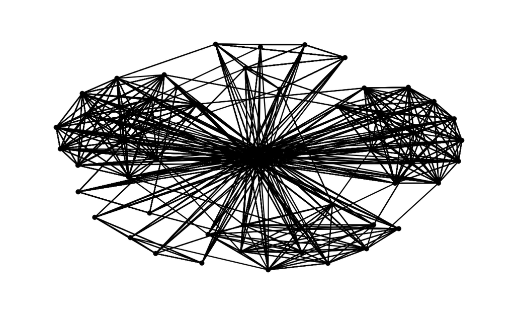

```r
set.seed(1234)
ggraph(GAStech_graph,
       layout = "stress") + # random
  geom_edge_link() +
  geom_node_point() +
  theme_graph() # remove gray background
```

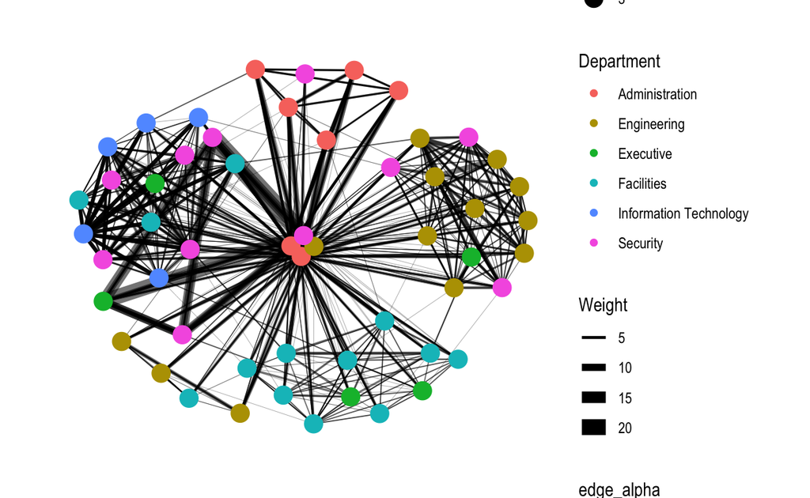

```r
set.seed(1234)
ggraph(GAStech_graph,
       layout = "stress") + # random
  geom_edge_link(aes(width=Weight,alpha=0.2)) +
  scale_edge_width(range = c(0.1,5))+
  geom_node_point(aes(color=Department,
                      size = 3)) +
  theme_graph() # remove gray background
```

## Working with facet

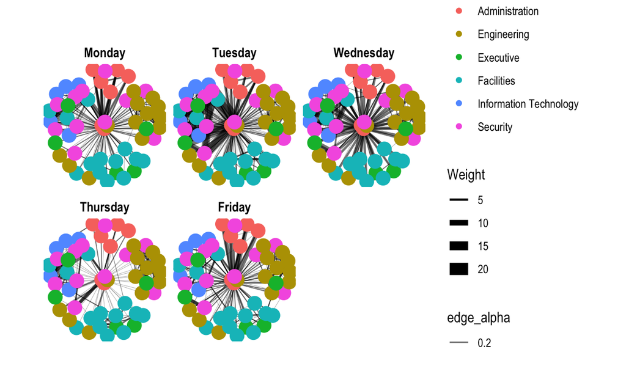

```r
set.seed(1234)
ggraph(GAStech_graph,
       layout = "stress") + # random
  geom_edge_link(aes(width=Weight,alpha=0.2)) +
  scale_edge_width(range = c(0.1,5))+
  geom_node_point(aes(color=Department,
                      size = 1)) +
  theme_graph() + # remove gray background
  facet_edges(~Weekday)
```

## Change the facet

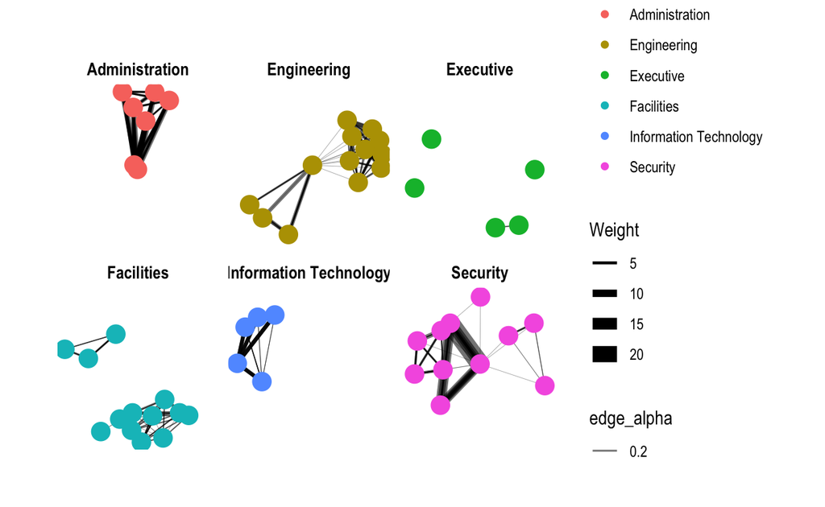

```r
set.seed(1234)
ggraph(GAStech_graph,
       layout = "stress") + # random
  geom_edge_link(aes(width=Weight,alpha=0.2)) +
  scale_edge_width(range = c(0.1,5))+
  geom_node_point(aes(color=Department,
                      size = 1)) +
  theme_graph() + # remove gray background
  facet_nodes(~Department)
```

## Network with centrality metric

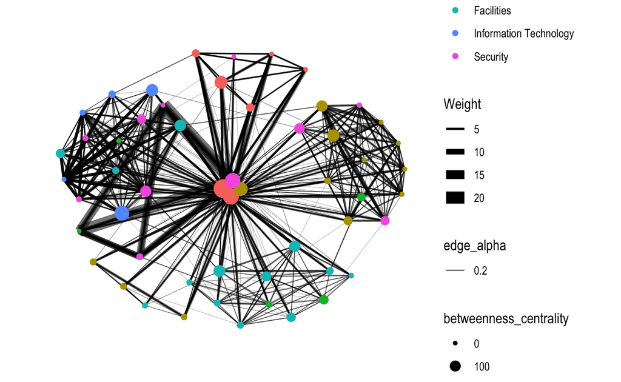

```r
GAStech_graph %>%
  mutate(betweenness_centrality = centrality_betweenness()) %>%
  ggraph(
       layout = "stress") + # random
  geom_edge_link(aes(width=Weight,
                     alpha=0.2)) +
  scale_edge_width(range = c(0.1,5))+
  geom_node_point(aes(color=Department,
                      size = betweenness_centrality)) +
  theme_graph()
```

## Visualising Community

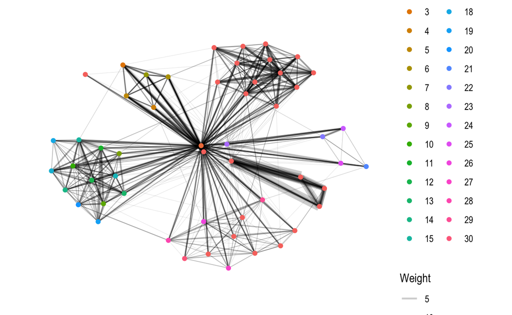

```r
g <- GAStech_graph %>%
  mutate(community = as.factor(group_edge_betweenness(weights = Weight, directed = TRUE))) %>%
  ggraph(layout = "fr") +
  geom_edge_link(aes(width=Weight),
                 alpha=0.2) +
  scale_edge_width(range = c(0.1, 5)) +
  geom_node_point(aes(colour = community))
g + theme_graph()
```

## Building Interactive Network Graph with visNetwork

visNetwork() is a R package for network visualization, using vis.js javascript library.

visNetwork() function uses a nodes list and edges list to create an interactive graph.

The nodes list must include an “id” column, and the edge list must have “from” and “to” columns. The function also plots the labels for the nodes, using the names of the actors from the “label” column in the node list. The resulting graph is fun to play around with.

You can move the nodes and the graph will use an algorithm to keep the nodes properly spaced. You can also zoom in and out on the plot and move it around to re-center it.

```r
GAStech_edges_aggregated <- GAStech_edges %>%
  left_join(GAStech_nodes, by = c("sourceLabel" = "label")) %>%
  rename(from = id) %>%
  left_join(GAStech_nodes, by = c("targetLabel" = "label")) %>%
  rename(to = id) %>%
  filter(MainSubject == "Work related") %>%
  group_by(from, to) %>%
    summarise(weight = n()) %>%
  filter(from!=to) %>%
  filter(weight > 1) %>%
  ungroup()
visNetwork(GAStech_nodes,
           GAStech_edges_aggregated)
```

[interactive chart not shown]

## Working with layout

In the code chunk below, Fruchterman and Reingold layout is used.

```r
 visNetwork(GAStech_nodes,
            GAStech_edges_aggregated) %>%
   visIgraphLayout(layout = "layout_with_fr")
```

[interactive chart not shown]

Visit Igraph to find out more about visIgraphLayout’s argument.

## Working with visual attributes - Nodes

visNetwork() looks for a field called “group” in the nodes object and colour the nodes according to the values of the group field.

The code chunk below rename Department field to group.

```r
GAStech_nodes <- GAStech_nodes %>%
  rename(group = Department)
```

## Working with visual attributes - Nodes

When we rerun the code chunk below, visNetwork shades the nodes by assigning unique colour to each category in the group field.

```r
visNetwork(GAStech_nodes,
           GAStech_edges_aggregated) %>%
  visIgraphLayout(layout = "layout_with_fr") %>%
  visLegend() %>%
  visLayout(randomSeed = 123)
```

[interactive chart not shown]

## Working with visual attributes - Edges

In the code run below visEdges() is used to symbolise the edges.

- The argument arrows is used to define where to place the arrow.
- The smooth argument is used to plot the edges using a smooth curve.

```r
visNetwork(GAStech_nodes,
           GAStech_edges_aggregated) %>%
  visIgraphLayout(layout = "layout_with_fr") %>%
  visEdges(arrows = "to",
           smooth = list(enabled = TRUE,
                         type = "curvedCW")) %>%
  visLegend() %>%
  visLayout(randomSeed = 123)
```

[interactive chart not shown]